# HW5A - Recidivism Memo

The aspect of cost/benefit estimates the revenues associated with using the improved model under the following scenario. The cost-benefit table is as Table 1.

```
(1) True Positive: The person was predicted to recidivate and actually recidivated. Allocated one-third of the education resources, the annual education cost of $1,200 per person is included in the cost.[2] Since recidivated ex-offenders are estimated to cost the state of Pennsylvania $45,000 per year, it is also included in the cost.[3] No benefit is generated because the person recidivated.
   - Cost: ( -$100 × 12 months for education -$45,000 ) × Count
   - Benefit: 0

(2) True Negative: The person was predicted not to recidivate and actually did not recidivate. Allocated 100% of the education resources, the annual education cost of $3,600 per person is included in the cost. Assuming the person get a job and get minimum wage, the benefit is calculated as $7.25/hr × 40hr/week × 52 weeks/yr = $15,080 [4]
   - Cost: ( -$300 × 12 months for education ) × Count
   - Benefit: $15,080 × Count

(3) False Positive: The person was predicted to recidivate and actually did not recidivate. Allocated one-third of the education resources, the annual education cost of $1,200 per person is included in the cost. Assuming the person get a job and get minimum wage, the benefit is calculated as $7.25/hr × 40hr/week × 52 weeks/yr = $15,080.
   - Cost: ( -$100 × 12 months for education ) × Count
   - Benefit: $15,080 × Count

(4) False Negative: The person was predicted not to recidivate and actually recidivated. Allocated 100% of the education resources, the annual education cost of $3,600 per person is included in the cost. No benefit is generated because the person recidivated.
   - Cost: ( -$300 × 12 months for education -$45,000 ) × Count
   - Benefit: $0
```

```r
iterateThresholds <- function(data, observedClass, predictedProbs, group) {
  observedClass <- enquo(observedClass)
  predictedProbs <- enquo(predictedProbs)
  group <- enquo(group)
  x = .01
  all_prediction <- data.frame()

  if (missing(group)) {

    while (x <= 1) {
    this_prediction <- data.frame()

    this_prediction <-
      data %>%
      mutate(predclass = ifelse(!!predictedProbs > x, 1,0)) %>%
      count(predclass, !!observedClass) %>%
      summarize(Count_TN = sum(n[predclass==0 & !!observedClass==0]),
                Count_TP = sum(n[predclass==1 & !!observedClass==1]),
                Count_FN = sum(n[predclass==0 & !!observedClass==1]),
                Count_FP = sum(n[predclass==1 & !!observedClass==0]),
                Rate_TP = Count_TP / (Count_TP + Count_FN),
                Rate_FP = Count_FP / (Count_FP + Count_TN),
                Rate_FN = Count_FN / (Count_FN + Count_TP),
                Rate_TN = Count_TN / (Count_TN + Count_FP),
                Accuracy = (Count_TP + Count_TN) /
                           (Count_TP + Count_TN + Count_FN + Count_FP)) %>%
      mutate(Threshold = round(x,2))

    all_prediction <- rbind(all_prediction,this_prediction)
    x <- x + .01
  }
  return(all_prediction)
  }
  else if (!missing(group)) {
   while (x <= 1) {
    this_prediction <- data.frame()

    this_prediction <-
      data %>%
      mutate(predclass = ifelse(!!predictedProbs > x, 1,0)) %>%
      group_by(!!group) %>%
      count(predclass, !!observedClass) %>%
      summarize(Count_TN = sum(n[predclass==0 & !!observedClass==0]),
                Count_TP = sum(n[predclass==1 & !!observedClass==1]),
                Count_FN = sum(n[predclass==0 & !!observedClass==1]),
                Count_FP = sum(n[predclass==1 & !!observedClass==0]),
                Rate_TP = Count_TP / (Count_TP + Count_FN),
                Rate_FP = Count_FP / (Count_FP + Count_TN),
                Rate_FN = Count_FN / (Count_FN + Count_TP),
                Rate_TN = Count_TN / (Count_TN + Count_FP),
                Accuracy = (Count_TP + Count_TN) /
                           (Count_TP + Count_TN + Count_FN + Count_FP)) %>%
      mutate(Threshold = round(x, 2))

    all_prediction <- rbind(all_prediction, this_prediction)
    x <- x + .01
  }
  return(all_prediction)
  }
}

testProbs.thresholds <-
  iterateThresholds(data=testProbs, observedClass = class,
                    predictedProbs = probs, group = Race)

testProbs.thresholds_All <-
  iterateThresholds(data=testProbs, observedClass = class,
                    predictedProbs = probs)
```

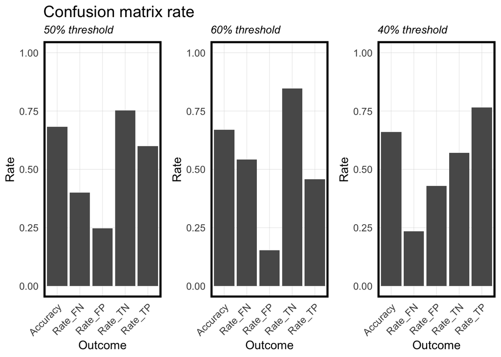

```r
grid.arrange(ncol = 3,
filter(testProbs.thresholds_All, Threshold == .5)  %>%
  dplyr::select(Accuracy, starts_with("Rate")) %>%
  gather(Variable, Value) %>%
    ggplot(aes(Variable, Value)) +
      geom_bar(stat = "identity") +
      ylim(0,1)+
      labs(title="Confusion matrix rate",
           subtitle = "50% threshold", x = "Outcome",y = "Rate") +
      plotTheme() + theme(axis.text.x = element_text(angle = 45, hjust = 1)),
filter(testProbs.thresholds_All, Threshold == .6)  %>%
  dplyr::select(Accuracy, starts_with("Rate")) %>%
  gather(Variable, Value) %>%
    ggplot(aes(Variable, Value)) +
      geom_bar(stat = "identity") +
      ylim(0,1)+
      labs(title="",
           subtitle = "60% threshold", x = "Outcome",y = "Rate") +
      plotTheme() + theme(axis.text.x = element_text(angle = 45, hjust = 1)),
filter(testProbs.thresholds_All, Threshold == .4)  %>%
  dplyr::select(Accuracy, starts_with("Rate")) %>%
  gather(Variable, Value) %>%
    ggplot(aes(Variable, Value)) +
      geom_bar(stat = "identity") +
      ylim(0,1)+
      labs(title="",
           subtitle = "40% threshold", x = "Outcome",y = "Rate") +
      plotTheme() + theme(axis.text.x = element_text(angle = 45, hjust = 1)))
```

```r
cost_benefit_table <-
   testProbs.thresholds_All %>%
       mutate(Revenue_TP = Count_TP * ((-100 * 12) + (-45000)),
              Revenue_TN = Count_TN * ((-300 * 12) + 15080),
              Revenue_FP = Count_FP * ((-100 * 12) + 15080),
              Revenue_FN = Count_FN * ((-300 * 12) + (-45000)),
              Revenue_Total = Revenue_TP + Revenue_TN + Revenue_FP + Revenue_FN)
cost_benefit_table_pivot <- cost_benefit_table %>%
  pivot_longer(
    cols = c(Revenue_TP, Revenue_TN, Revenue_FP, Revenue_FN, Revenue_Total),
    names_to = "Variable",
    values_to = "Revenue"
  )
cost_benefit_table_pivot %>%
  dplyr::select(Threshold, Variable, Revenue) %>%
  filter(Threshold==0.40 | Threshold==0.50 | Threshold==0.60) %>%
  kable(caption = "Table 1 Cost/Benefit Table by threshold") %>% kable_styling()
```

Table 1 Cost/Benefit Table by threshold

| Threshold | Variable | Revenue |
| --- | --- | --- |
| 0.4 | Revenue_TP | -24855600 |
| 0.4 | Revenue_TN | 5487440 |
| 0.4 | Revenue_FP | 4982920 |
| 0.4 | Revenue_FN | -8019000 |
| 0.4 | Revenue_Total | -22404240 |
| 0.5 | Revenue_TP | -19496400 |
| 0.5 | Revenue_TN | 7232400 |
| 0.5 | Revenue_FP | 2873160 |
| 0.5 | Revenue_FN | -13656600 |
| 0.5 | Revenue_Total | -23047440 |
| 0.6 | Revenue_TP | -14876400 |
| 0.6 | Revenue_TN | 8139320 |
| 0.6 | Revenue_FP | 1776640 |
| 0.6 | Revenue_FN | -18516600 |
| 0.6 | Revenue_Total | -23477040 |

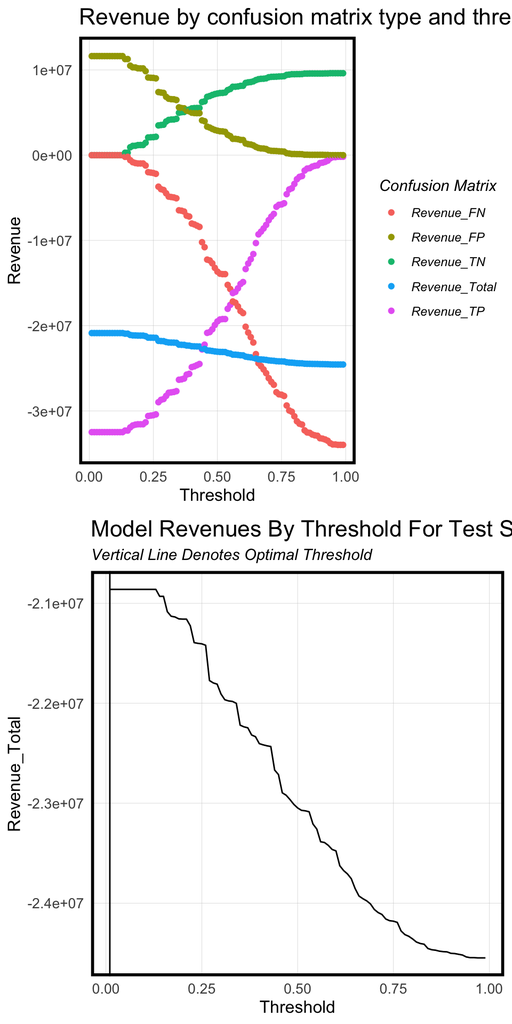

```r
whichThreshold <- cost_benefit_table %>%
  dplyr::select(Threshold, Revenue_TP, Revenue_TN, Revenue_FP, Revenue_FN, Revenue_Total) %>%
  pivot_longer(cols = c(Revenue_TP, Revenue_TN, Revenue_FP, Revenue_FN, Revenue_Total),
               names_to = "Variable", values_to = "Revenue") %>%
  ggplot() +
  geom_point(aes(x = Threshold, y = Revenue, colour = Variable)) +
   scale_fill_manual(values = palette_9_colors) +
   plotTheme()+
  labs(title = "Revenue by confusion matrix type and threshold",
       y = "Revenue") +
  guides(colour = guide_legend(title = "Confusion Matrix"))

modelRevenue <- cost_benefit_table %>%
         dplyr::select(Threshold, Revenue_Total) %>%
ggplot()+
  geom_line(aes(x = Threshold, y = Revenue_Total))+
  geom_vline(xintercept =  pull(arrange(cost_benefit_table %>%
         dplyr::select(Threshold, Revenue_Total), -Revenue_Total)[1,1]))+
  plotTheme()+
    labs(title = "Model Revenues By Threshold For Test Sample",
         subtitle = "Vertical Line Denotes Optimal Threshold")

grid.arrange(whichThreshold, modelRevenue, ncol=1)
```

3. Aspect of Fairness

By race, Caucasians are treated more tolerate than African-Americans. African-Americans have a higher recidivism rate than Caucasians. However, the False Positive rate for African-Americans is also higher than that for Caucasians, and the False Negative rate for African-Americans is lower than that for Caucasians. This fairness issue varies depending on the threshold, as shown in Figure 3. Since we should consider trade off between the fairness and the accuracy of the model, we accept the threshold 0.4 as the optimal threshold.

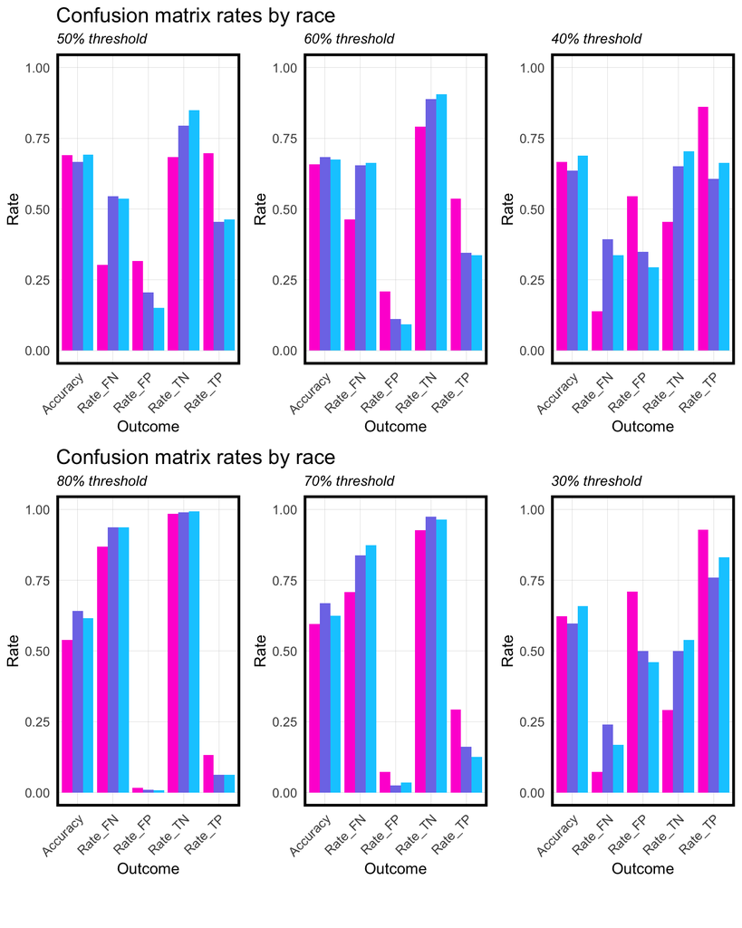

```r
plot1 <- filter(testProbs.thresholds, Threshold == .5)  %>%
  dplyr::select(Accuracy, Race, starts_with("Rate")) %>%
  gather(Variable, Value, -Race) %>%
    ggplot(aes(Variable, Value, fill = Race)) +
      geom_bar(aes(fill = Race), position = "dodge", stat = "identity") +
      ylim(0,1)+
      scale_fill_manual(values = palette_3_colors) +
      labs(title="Confusion matrix rates by race",
           subtitle = "50% threshold", x = "Outcome",y = "Rate") +
      plotTheme() + theme(axis.text.x = element_text(angle = 45, hjust = 1), legend.position="none")

plot2 <- filter(testProbs.thresholds, Threshold == .6)  %>%
  dplyr::select(Accuracy, Race, starts_with("Rate")) %>%
  gather(Variable, Value, -Race) %>%
    ggplot(aes(Variable, Value, fill = Race)) +
      geom_bar(aes(fill = Race), position = "dodge", stat = "identity") +
      ylim(0,1)+
      scale_fill_manual(values = palette_3_colors) +
      labs(title="",
           subtitle = "60% threshold", x = "Outcome",y = "Rate") +
      plotTheme() + theme(axis.text.x = element_text(angle = 45, hjust = 1), legend.position="none")

plot3 <- filter(testProbs.thresholds, Threshold == 0.4)  %>%
  dplyr::select(Accuracy, Race, starts_with("Rate")) %>%
  gather(Variable, Value, -Race) %>%
    ggplot(aes(Variable, Value, fill = Race)) +
      geom_bar(aes(fill = Race), position = "dodge", stat = "identity") +
      ylim(0,1)+
      scale_fill_manual(values = palette_3_colors) +
      labs(title="",
           subtitle = "40% threshold", x = "Outcome",y = "Rate") +
      plotTheme() + theme(axis.text.x = element_text(angle = 45, hjust = 1), legend.position="none")

plot4 <- filter(testProbs.thresholds, Threshold == .8)  %>%
  dplyr::select(Accuracy, Race, starts_with("Rate")) %>%
  gather(Variable, Value, -Race) %>%
    ggplot(aes(Variable, Value, fill = Race)) +
      geom_bar(aes(fill = Race), position = "dodge", stat = "identity") +
      ylim(0,1)+
      scale_fill_manual(values = palette_3_colors) +
      labs(title="Confusion matrix rates by race",
           subtitle = "80% threshold", x = "Outcome",y = "Rate") +
      plotTheme() + theme(axis.text.x = element_text(angle = 45, hjust = 1), legend.position="none")

plot5 <- filter(testProbs.thresholds, Threshold == .7)  %>%
  dplyr::select(Accuracy, Race, starts_with("Rate")) %>%
  gather(Variable, Value, -Race) %>%
    ggplot(aes(Variable, Value, fill = Race)) +
      geom_bar(aes(fill = Race), position = "dodge", stat = "identity") +
      ylim(0,1)+
      scale_fill_manual(values = palette_3_colors) +
      labs(title="",
           subtitle = "70% threshold", x = "Outcome",y = "Rate") +
      plotTheme() + theme(axis.text.x = element_text(angle = 45, hjust = 1), legend.position="none")

plot6 <- filter(testProbs.thresholds, Threshold == 0.3)  %>%
  dplyr::select(Accuracy, Race, starts_with("Rate")) %>%
  gather(Variable, Value, -Race) %>%
    ggplot(aes(Variable, Value, fill = Race)) +
      geom_bar(aes(fill = Race), position = "dodge", stat = "identity") +
      ylim(0,1)+
      scale_fill_manual(values = palette_3_colors) +
      labs(title="",
           subtitle = "30% threshold", x = "Outcome",y = "Rate") +
      plotTheme() + theme(axis.text.x = element_text(angle = 45, hjust = 1), legend.position="none")

legend <- get_legend(op)

grid.arrange(
  arrangeGrob(plot1, plot2, plot3, ncol = 3),
  arrangeGrob(plot4, plot5, plot6, ncol = 3),
  legend,
  ncol = 1,
  heights = c(10,10,1)
)
```